# S7d2: intervallo di confidenza dal test a inversione di segno

Roadmap Morris 2019, ramo morris-v4

Data di Pubblicazione

25 ottobre 2026

## In breve: invertendo il test a inversione di segno si ottiene un intervallo di confidenza utile per il paper?

**A cosa serviva.** Il test a inversione di segno sui contributi dei soggetti allo score è tarato e risponde quasi sempre, ma dà solo un p-value. Abbiamo costruito l’intervallo di confidenza dell’interazione trattamento per tempo che si ottiene invertendo il test: l’insieme dei valori dell’effetto che il test non rifiuta. Ne abbiamo misurato copertura e ampiezza su tutte le 2.376 situazioni dei quattro modi di generare i dati, con 1.000 simulazioni per scenario con e senza effetto del trattamento, e lo abbiamo confrontato con l’intervallo della strategia che il paper raccomanda: la GEE con correlazione AR(1), la correzione di Fay e Graubard e la t.

**Cosa abbiamo trovato.**

1. **L’intervallo contiene il valore vero come deve, in tutte le situazioni.**
   - Con l’effetto del trattamento lo contiene in 94,5 simulazioni su 100; la GEE raccomandata in 95,8.
   - In nessuna situazione è fuori taratura, né verso il basso né verso l’alto.
2. **Con pochi soggetti e poche visite l’intervallo è quasi sempre illimitato.**
   - Con 2-3 visite e fino a 25 soggetti ha entrambi gli estremi finiti in 14 simulazioni su 100; la GEE raccomandata dà un intervallo in 47. Sull’intera griglia è finito in 79 su 100.
   - Il motivo: con pochi eventi i dati non escludono effetti estremi e il test non riesce a rifiutarli. L’intervallo della GEE è finito per costruzione, perché è simmetrico attorno alla stima.
3. **Dove entrambi esistono, l’intervallo dal test è più largo, in media del 17%.**
   - Il divario si chiude con i dati: 6% in più con almeno 75 soggetti, 3% con 10 visite; quasi il doppio con 2-3 visite e fino a 25 soggetti.
   - Non dipende dalla correlazione di lavoro: la GEE con correlazione indipendente, la stessa del test, è larga quasi come quella con AR(1) (2% in più).
4. **Il test del passaggio precedente rispondeva anche dove i dati non contengono l’informazione, con un p-value casuale.**
   - Quando in un braccio tutti gli esiti sono 0, i dati non dicono nulla sull’andamento nel tempo di quel braccio e l’interazione non si può stimare. Il test restituiva comunque un p-value, fatto di solo errore di arrotondamento.
   - Succede in 28 simulazioni su 100 con 2-3 visite e fino a 25 soggetti (circa 6 su 10 con 10 soggetti e 2 visite) e in 3,5 su 100 sull’intera griglia.
   - Se questi casi si contano come “test non calcolabile”, con 2-3 visite e fino a 25 soggetti il test risponde in 72 simulazioni su 100 invece di quasi tutte; la GEE raccomandata in 46. Resta tarato: 5,2 falsi positivi su 100 in quelle situazioni, 5,4 sull’intera griglia, mai fuori taratura.

**Cosa devi decidere.**

1. **Come entra l’intervallo nel paper? Consiglio di non proporlo: una frase nella discussione e il dettaglio nel supplemento.**
   - Contiene il valore vero come deve, ma proprio dove servirebbe (2-3 visite, pochi soggetti) è quasi sempre illimitato, e altrove è più largo di quello della GEE raccomandata: non aggiunge un intervallo utilizzabile.
   - Il test resta, come già deciso, un’analisi complementare che dice se c’è un effetto e in che direzione.
   - Alternativa: presentarlo nel testo principale accanto al test, con una tabella. Il paper offrirebbe test e intervallo dallo stesso metodo, ma con un intervallo spesso illimitato da spiegare.
   - Alternativa: non parlarne. È la più semplice, ma un revisore potrebbe chiedere perché il test non ha un intervallo.
2. **Nel paper il test riconosce i casi in cui non è calcolabile? Consiglio di sì.**
   - Un p-value fatto di errore di arrotondamento non è una risposta; con la regola il test resta tarato ovunque.
   - Conseguenza: la frase del paper diventa “con 2-3 visite e fino a 25 soggetti il test risponde in circa 3 casi su 4, la GEE raccomandata in circa 1 su 2” invece di “quasi sempre”. I numeri del test si ricalcolano da questo run, senza nuove simulazioni.
   - Alternativa: tenere il test com’era e dichiarare che in circa un quarto delle simulazioni con pochi dati il suo p-value non contiene informazione. Cambia meno il testo, ma il paper conterebbe risposte del test che sappiamo vuote.

**Comunque:**

- quando riscriveremo il paper, le frasi sul test a inversione di segno useranno questi numeri, e la copertura dell’intervallo entrerà almeno nel supplemento;
- i due controlli falliti alla lettera (il p-value al centro dell’intervallo non sempre uguale a 1, e 78 intervalli su 4,5 milioni con un punto non calcolabile subito oltre l’estremo) sono spiegati nel report e non toccano nessun risultato.

Appena decidi questi 2 punti, lo step è chiuso.

Il PI ha deciso i 2 punti il 2026-10-25, accogliendo le due raccomandazioni: step chiuso.

**Sui tempi di calcolo.** Il run è durato 8,0 ore sul server con 22-26 processi regolati dalla temperatura. L’agente aveva stimato 7-9 ore dai tempi misurati nella prova (0,14 secondi per dataset su 360 dataset, con 18 processi). La stima di circa 9 ore del passaggio precedente non era misurata.

# Dubbi rinviati

Rinviato all’Aggiornamento del manoscritto con le analisi aggiunte (S7f), che lo riceve nel suo file: il testo da scrivere sui risultati di questo step e i numeri del test ricalcolati con le regole.

# Cancelli e previsioni

Attese pre-registrate (commit `3235dbe`, prima di ogni calcolo):

**Test a b0.** Stessa costruzione del test principale del run S7d (Test a inversione di segno: principale senza filtro sui coefficienti del modello ridotto, con il filtro come sensibilita’ (D-47); `R/s7d/s7d_flip.R`), con il nullo time:trt = b0 imposto dall’offset b0 * time * trt nel modello ridotto (modello medio della GEE dello scenario senza `time:trt`, correlazione di lavoro indipendente, `glm.fit`, `epsilon = 1e-12`, `maxit = 100`). Contributi effettivi allo score per soggetto u_i(b0) come in Hemerik e colleghi[^hemerik2020]; statistica abs(sum_i g_i u_i(b0)). La matrice dei segni g e’ una sola per dataset, la stessa per ogni b0: tutti i 2^N segni se N <= 12, altrimenti 1.999 segni casuali piu’ l’identita’, estratti dopo `set.seed(20261022 + i)` esattamente come nel run S7d, cosi’ il p-value a b0 = 0 coincide con quello gia’ salvato. Si rifiuta se p < 0,05 (come nell’errore di I tipo del run S7d). Un b0 a cui il modello ridotto non converge o ha valori non finiti conta come “non rifiutato” (scelta prudente, allarga l’intervallo) e si conta.

**Stima puntuale.** La stima della GEE con correlazione indipendente (GLM logistico completo, stesso `glm.fit`), che e’ lo zero della somma dei contributi: li’ il p-value vale 1. Serve da centro della ricerca e da stima da riportare insieme all’intervallo. Se il fit completo non converge, ha valori non finiti o |stima| >= 10, l’intervallo non si calcola (dataset senza intervallo).

**Ricerca degli estremi**, per lato: passi dal centro di s, 2s, 4s, … (s = errore standard del fit completo basato sul modello; se non finito, 0,1), troncati a |b0| = 10; al primo b0 rifiutato si passa alla bisezione fra l’ultimo accettato e il primo rifiutato, fino a una forbice sotto 1e-4; l’estremo riportato e’ il lato accettato. Se b0 = +/-10 non e’ rifiutato, quel lato e’ illimitato. L’intervallo riportato e’ quindi il tratto di valori accettati attorno alla stima trovato da questa ricerca.

**Valore vero** (protocollo, sez. 3; marginale): GenBinaryY e copula, il `beta` del generatore (0,2; 0,05 in M4; 0 sotto H0); GLMM-AR1, il target (marginale per costruzione su ogni replicato); GLMM-native, il limite della GEE di indipendenza pesato sul disegno realizzato (`tables/V4_S4_truth_by_cell.csv` per M1-M5 e M1c, `tables/V4_S6b_ns_truth.csv` per M6-M7; sotto H0 da -0,0011 a -0,0030). E’ lo stesso estimando del test, che usa la correlazione di lavoro indipendente.

**Misure** (per punto e braccio; denominatore: replicati con disegno stimabile, Replicati con disegno non stimabile esclusi dal denominatore (D-11)):

- copertura del test: quota di dataset in cui il test al valore vero non rifiuta, fra quelli con p-value finito al valore vero (misura principale: e’ la copertura dell’insieme di confidenza, qualunque forma abbia);
- copertura dell’intervallo riportato: quota con estremo inferiore <= valore vero <= estremo superiore, fra i dataset con intervallo calcolato (estremi illimitati ammessi);
- quota con intervallo finito: dataset con entrambi gli estremi finiti sui replicati con disegno stimabile;
- ampiezza: estremo superiore meno inferiore, sui dataset con intervallo finito;
- rapporto di ampiezza con la GEE AR(1) con Fay e Graubard e t a N - p (ampiezza 2 t_{0,975; N-p} SE), sui dataset in cui entrambi danno un intervallo finito (la GEE: usabile come nel run S7d); per punto la media geometrica dei rapporti, cioe’ exp della media dei log-rapporti;
- per confronto, la copertura della GEE AR(1) con Fay e Graubard e t sugli stessi punti.

“Situazioni piccole”: 2-3 visite e fino a 25 soggetti, 216 punti (i 176 dei tre meccanismi dello studio piu’ 40 della copula).

## Cancelli

| codice | controllo | passa se |
| --- | --- | --- |
| GG1 | integrita’ e completezza | md5 di `results_full/` prima e dopo il run uguali fra loro e alla lista di S7b; `R/testing/test_h0h1_parity.R` passa prima del run; 47.520 file di chunk e 4.752.000 replicati, ognuno con la sua riga |
| GG2 | stessi dataset e stesso test | per ogni replicato, numero di osservazioni e somma degli esiti uguali a quelli salvati nei run S7d e S7e, e p-value a b0 = 0 uguale a `p_flip` salvato (uguali, oppure mancanti insieme), sia chiamando … |
| GG3 | controprova indipendente, prima del run | su 1.080 dataset (27 combinazioni meccanismo x scenario: 22 dei tre meccanismi dello studio e 5 della copula; N 10 e 25; T 3 e 10, in M1c 3 e 6; replicati 1-5; H0 e H1): (a) a b0 = 0,1 e b0 = -0,3 il … |
| GG4 | coerenza dell’intervallo nel run | in ogni dataset con intervallo: estremo inferiore <= stima <= estremo superiore, p-value >= 0,05 ai due estremi riportati (finiti) e < 0,05 a 1e-4 oltre ciascuno |

## Previsioni

Margini della skill salvo dove motivato: copertura da 92,5% a 97,5%; differenze fra versioni o metodi +/- 1 punto in media sui punti. Aggregato = media sui 2.376 punti (H1 salvo dove indicato), intervallo dal bootstrap per blocchi. Le bandiere “chiaramente sopra / sotto” (stima +/- 2 MCSE oltre la soglia, con almeno 20 dataset usabili) si contano come interi.

| codice | quantita’ | atteso | intervallo di rilevanza | perche’ conta |
| --- | --- | --- | --- | --- |
| PG1 | copertura del test al valore vero, H1, media sui 2.376 punti | 94,7% (sotto H0 il test rifiuta il 5,3% nei tre meccanismi dello studio e il 5,2% nella copula) | da 92,5% a 97,5% | se fuori, l’intervallo non si puo’ proporre nel paper |
| PG2 | punti con copertura del test chiaramente sotto 92,5%, H1 | 0 | 0 | un punto toglierebbe la frase “tarato in tutte le situazioni”, come per l’errore di I tipo |
| PG3 | punti con copertura del test chiaramente sopra 97,5%, H1 | 10 (sotto H0 il test era chiaramente sotto 2,5% in 4 punti) | da 0 a 60 | oltre 60 (circa meta’ dei 136 punti in cui la GEE AR(1) con Fay e Graubard e’ prudente) cambierebbe la frase “prudente solo dove i dati non hanno quasi informazione” |
| PG4 | copertura dell’intervallo riportato meno copertura del test, H1, media sui punti | 0 punti | da -1 a +1 | fuori, l’insieme dei valori accettati non e’ un intervallo e il tratto riportato non ne rappresenta la copertura |
| PG5 | quota con intervallo finito, H1, media sui 2.376 punti | 97% | da 90% a 100% | sotto 90% il test darebbe spesso un p-value senza un intervallo utilizzabile |
| PG6 | quota con intervallo finito, H1, media sui 216 punti piccoli | 80% (GEE AR(1) con Fay e Graubard usabile circa 44%) | da 60% a 100% | sotto 60% l’intervallo chiuderebbe solo in parte il limite sulle 2-3 visite con pochi soggetti |
| PG7 | rapporto di ampiezza intervallo del test / GEE AR(1) con Fay e Graubard e t, H1, media geometrica sui punti | 1,00 | da 0,90 a 1,10 | fuori, il paper dira’ “piu’ stretto” o “piu’ largo” invece di “simile” |
| PG8 | copertura della GEE AR(1) con Fay e Graubard e t, H1, media sui 2.376 punti | 95,5% (sotto H0 rifiuta il 4,3%) | da 92,5% a 97,5% | serve al confronto: se fuori, il confronto di ampiezza va letto insieme alla copertura |

Prima di fissare i margini: la MCSE della copertura per punto e’ circa 0,7 punti (1.000 replicati); l’intervallo per blocchi delle medie sui punti nei run precedenti era sotto +/- 0,05 punti per le quote, quindi margini di +/- 1 punto e intervalli larghi 5 punti non sono indeterminati per costruzione. Le MCSE di PG5-PG7 si leggono dal bootstrap.

Fuori dalle previsioni, riportati: forma dell’insieme dei valori accettati sui 1.080 dataset della controprova (p-value su una griglia fitta di 2.001 valori fra estremo inferiore - ampiezza e superiore + ampiezza: quota di dataset in cui i valori accettati non formano un solo tratto); copertura sotto H0 (circa 1 meno l’errore di I tipo), ampiezze per T e N, numero di valutazioni del test per dataset, valori di b0 non valutabili.

Esito (calcolo del 2026-10-25):

Run: `R/s7d2/s7d2_run.R`, 47.512 chunk (piu’ gli 8 della prova a secco: 47.520, 4.752.000 dataset), 22-26 processi regolati dalla temperatura (Tctl fra 63 e 74 gradi), 7,98 ore, 0 chunk falliti; codice e aggregazione committati prima del run (`b431042`). Aggregazione `R/s7d2/s7d2_agg.R`; spiegazioni scritte dopo il run: `s7d2_explain.R`, `s7d2_flip_rules.R`, `s7d2_width_groups.R`, `s7d2_zerowidth.R`. Tabelle `tables/V4_S7d2_*.csv`.

Correzioni dell’aggregazione dopo il run (strumento, non analisi): (1) la tabella delle previsioni prendeva sempre la prima riga delle medie per un nome di variabile uguale a una colonna (`row_bm`), corretto; (2) 51 intervalli finiti hanno ampiezza 0 (centro non calcolabile, vicini rifiutati, p-value costante in b0; 10-15 soggetti, 2-4 visite): restano nella quota di intervalli finiti ma non entrano nel rapporto di ampiezza, dove il loro log(0) contava come rapporto 1; PG7 passa da 1,1664 a 1,1667.

## Cancelli

| codice | esito | dettaglio |
| --- | --- | --- |
| GG1 | passa | 47.520 chunk, 4.752.000 replicati unici; md5 dei 28.800 file di `results_full/` prima = dopo = lista di S7b; parita’ H0/H1 passa |
| GG2 | passa | in tutti i 4.752.000 dataset numero di osservazioni, somma degli esiti e p-value a b0 = 0 (con `s7d_flip()` e con la funzione nuova) identici a quelli salvati; 0 errori |
| GG3 | (a) passa, (b) fallito come scritto e spiegato, (c) passa | vedi “Correzioni e controlli prima del run” |
| GG4 | fallito come scritto, spiegato | su 4.502.130 intervalli: 0 con stima fuori dall’intervallo, 0 estremi rifiutati; in 78 il punto 1e-4 oltre un estremo finito non e’ rifiutato perche’ li’ il test non e’ calcolabile (51 fit ridotti non… |

## Previsioni

[output not shown]

**PG5 e PG6 smentite, spiegazione** (`tables/V4_S7d2_explain_finite.csv`). La quota di intervalli finiti dipende da visite e soggetti: con 2 visite e’ 0,9% con 10 soggetti, 6,2% con 15-25, 22,7% con 35-65, 72,0% con 75-145; con 10 visite e’ 55,9%, 92,0%, 99,9% e 100%. Con pochi dati non finito vuol dire: (i) nessuna stima (GLM di indipendenza con |stima| >= 10: 57% con 10 soggetti e 2 visite); (ii) test non rifiutato fino a |b0| = 10, dopo aver incontrato valori non calcolabili (fit divergente o score nullo; 34% con 10 soggetti e 2 visite); (iii) test non rifiutato fino a 10 senza valori non calcolabili (48% con 35-65 soggetti e 2 visite). Con esiti binari e pochi eventi i dati non escludono odds ratio estremi: l’intervallo per inversione lo dice, l’intervallo di Wald della GEE e’ finito per costruzione. La previsione supponeva che l’intervallo fosse quasi sempre finito come le strategie di Wald; lo scarto e’ rilevante e tocca una conclusione (l’intervallo non chiude il limite sulle 2-3 visite con pochi soggetti): scelta del PI sotto.

**PG7 smentita, spiegazione** (`tables/V4_S7d2_width_groups.csv`, `V4_S7d2_explain_width.csv`). Il rapporto di ampiezza scende con soggetti e visite: 1,64 con 10 soggetti, 1,34 con 15-25, 1,15 con 35-65, 1,06 con 75-145; 1,53 con 2 visite, 1,03 con 10; 1,95 nelle 216 situazioni piccole. La correlazione di lavoro pesa poco: sugli stessi dataset la GEE con correlazione indipendente (lo stesso modello del test) e’ larga 1,02 volte la AR(1). L’eccesso viene quindi dall’inversione del test con pochi dati e si annulla al crescere di N e T, come atteso per un test score asintoticamente equivalente al Wald. Tocca la frase “ampiezza simile”: parte della stessa scelta.

## Dubbio aperto durante la preparazione: chiusura con il calcolo

`tables/V4_S7d2_flip_rules.csv` (test a b0 = 0, stessi 4.752.000 dataset). Senza effetto del trattamento, nelle 216 situazioni piccole il test come nel run S7d risponde nel 99,88% dei dataset, con le regole di Correzioni dello strumento dell’intervallo prima del run: camminata a passi fissi, partenza da zero, test non calcolabile con fit divergente o score nullo (D-57) nel 72,27% (38,0% con 10 soggetti e 2 visite); la GEE AR(1) con Fay e Graubard e t e’ usabile nel 45,94%. Errore di I tipo con le regole: 5,21% nelle situazioni piccole (3,89% come nel run S7d: i p-value casuali lo rendevano prudente) e 5,45% su tutti i 2.376 punti (5,28%); punti chiaramente sopra 7,5%: 0 in entrambe le versioni; chiaramente sotto 2,5%: 0 con le regole, 4 come nel run S7d. Sull’intera griglia le risposte scendono dal 99,98% al 96,51%. Il dubbio e’ spiegato; come trattarlo nel paper e’ una scelta del PI (sotto).

Valori calcolati (`tables/V4_S7d2_predictions.csv`) e medie con bootstrap per blocchi (`tables/V4_S7d2_boot_means.csv`):

| code | obs | lo | hi | a | b | verdict |
| --- | --- | --- | --- | --- | --- | --- |
| PG1 | 94.5 | 94.47 | 94.53 | 92.5 | 97.5 | confirmed |
| PG2 | 0 | 0 | 0 | 0 | 0 | confirmed |
| PG3 | 0 | 0 | 0 | 0 | 60 | confirmed |
| PG4 | 0.5737 | 0.5614 | 0.5853 | -1 | 1 | confirmed |
| PG5 | 78.99 | 78.93 | 79.05 | 90 | 100 | refuted |
| PG6 | 13.61 | 13.45 | 13.76 | 60 | 100 | refuted |
| PG7 | 1.167 | 1.158 | 1.168 | 0.9 | 1.1 | refuted |
| PG8 | 95.8 | 95.77 | 95.83 | 92.5 | 97.5 | confirmed |

| q | est | lo | hi | sd |
| --- | --- | --- | --- | --- |
| PG1 coverage of the test at the truth, H1 | 94.5 | 94.47 | 94.53 | 0.01535 |
| PG4 coverage interval - coverage test, H1 | 0.5737 | 0.5614 | 0.5853 | 0.006006 |
| PG5 finite interval share, H1 | 78.99 | 78.93 | 79.05 | 0.03041 |
| PG6 finite interval share, H1, small points | 13.61 | 13.45 | 13.76 | 0.08341 |
| PG7 width ratio flip / GEE AR(1) FG t (geometric), H1 | 1.167 | 1.158 | 1.168 | 0.00274 |
| PG8 coverage GEE AR(1) FG t, H1 | 95.8 | 95.77 | 95.83 | 0.01424 |
| coverage of the test at the truth, H0 | 94.56 | 94.53 | 94.59 | 0.01546 |
| coverage GEE AR(1) FG t, H0 | 95.66 | 95.63 | 95.69 | 0.01396 |
| finite interval share, H0 | 78.18 | 78.12 | 78.24 | 0.03024 |
| coverage of the test, H1, copula | 94.5 | 94.44 | 94.57 | 0.03358 |
| coverage of the test, H1, study mechanisms | 94.5 | 94.47 | 94.53 | 0.01737 |
| width ratio, H1, small points | 1.946 | 1.812 | 1.99 | 0.04674 |
| coverage test - coverage GEE AR(1) FG t, H1 | -1.299 | -1.324 | -1.274 | 0.01309 |

# Correzioni e controlli prima del run

Le attese sopra restano come committate in `3235dbe`. Prima del run di produzione:

- **Integrita’**: md5 dei 28.800 file di `results_full/` uguali alla lista di S7b (0 differenze); `R/testing/test_h0h1_parity.R` passa (`reports/morris/S7d2_logs/md5_before.txt`, `parity_before.txt`).
- **Controprova (cancello GG3) e quattro correzioni dello strumento**, registrate in Correzioni dello strumento dell’intervallo prima del run: camminata a passi fissi, partenza da zero, test non calcolabile con fit divergente o score nullo (D-57). La ricerca per raddoppi pre-registrata saltava le regioni rifiutate; dove il fit ridotto diverge o l’interazione non e’ identificata (un braccio con soli esiti 0) il p-value era errore di arrotondamento. Correzioni: camminata a passi fissi di min(s, 1)/10, partenza da zero di ogni fit, test non calcolabile (quindi non rifiutato) con coefficiente >= 1e3 o contributi tutti sotto 1e-6. Il terzo punto di GG3 diventa: nessun tratto rifiutato largo almeno un passo dentro l’intervallo riportato. Esito sul codice finale (`GG3.txt`): (a) passa (offset uguale a `glm()` entro 0; score uguale a numDeriv in tutti i dataset calcolabili); (b) fallito come scritto, spiegato: in 309 dei 943 dataset con stima il p-value al centro non e’ 1 (fra 0,88 e 1 per contributi uguali fra soggetti con 10 soggetti, oppure non calcolabile dove lo score e’ nullo) e in 1 la somma al centro non e’ zero (fit completo quasi separato); nessun centro e’ rifiutato; (c) passa: 0 tratti rifiutati dentro i 570 intervalli finiti.
- **Prova a secco** (8 chunk, 800 dataset, `dry_agg.txt`): GG2 passa (dati e p-value a b0 = 0 identici a quelli salvati, 0 differenze), GG4 passa (0 violazioni).
- **Tempi** (`results_v4/S7d2/timing_pilot.csv`, 360 dataset in 36 punti, 18 processi): 0,14 s per dataset in media, circa 180 ore di processore, 7-9 ore con 20-26 processi.

## Dubbio aperto durante la preparazione

**Il test del run precedente risponde anche dove l’interazione non e’ identificata.** Quando un braccio ha solo esiti 0, i contributi allo score sono errore di arrotondamento (circa 1e-14) e il test principale di Test a inversione di segno: principale senza filtro sui coefficienti del modello ridotto, con il filtro come sensibilita’ (D-47) restituisce un p-value casuale. Nella prova a secco, nei dati generati sulla scala della popolazione con 10 soggetti e 2 visite e con l’effetto, il test “risponde” nel 100% dei dataset ma solo nel 39% lo score non e’ nullo. La frase di La regola della Figura 1 si applica alle strategie con stima e intervallo: sceglie la GEE AR(1) con Fay e Graubard e la t; il test a inversione di segno e’ complementare (D-50) (“risponde nel 99,9% con 2-3 visite e fino a 25 soggetti”) dipende da questo. Il run misura su tutta la griglia, per punto, la quota di risposte del test a b0 = 0 come nel run S7d e con le regole di Correzioni dello strumento dell’intervallo prima del run: camminata a passi fissi, partenza da zero, test non calcolabile con fit divergente o score nullo (D-57), e il suo errore di I tipo con le regole (riportato, non previsione; `tables/V4_S7d2_small.csv`).

Controprova sul codice finale (`tables/V4_S7d2_GG3.csv`):

| part | value | pass |
| --- | --- | --- |
| datasets generated | 1080 | NA |
| (a) offset fits compared | 2160 | NA |
| (a) glm.fit vs glm, max coef diff | 0 | TRUE |
| (a) score = numDeriv, datasets failing | 0 | TRUE |
| (b) datasets with centre | 943 | NA |
| (b) \|sum u\| at centre >= 1e-8 | 1 | FALSE |
| (b) p at centre != 1 | 309 | FALSE |
| (c) finite intervals | 570 | NA |
| (c) rejected run inside the interval at least one walk step wide | 0 | TRUE |
| reported: intervals with a narrower rejected run inside | 0 | NA |
| reported: median share of the interval rejected, among those | 0 | NA |
| reported: max share of the interval rejected | 0 | NA |
| reported: >1 accepted stretch on the dense window | 90 | NA |
| reported: min p at centre | 0.877 | NA |

La decisione tecnica sulle quattro correzioni, con la storia delle quattro versioni della controprova, e’ in `docs/decisions/D-57.md`; i log di ogni versione in `reports/morris/S7d2_logs/`.

# Risultati

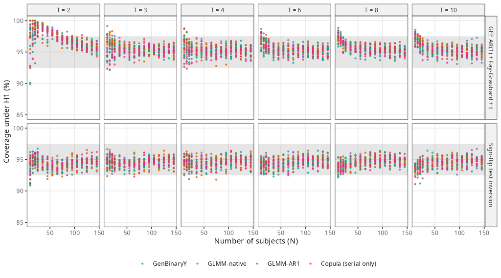

Copertura sotto H1, per punto di disegno (fascia grigia 92,5-97,5%; punti con almeno 20 dataset usabili). Sopra la GEE AR(1) con Fay e Graubard e t, sotto l’insieme dei valori non rifiutati dal test.

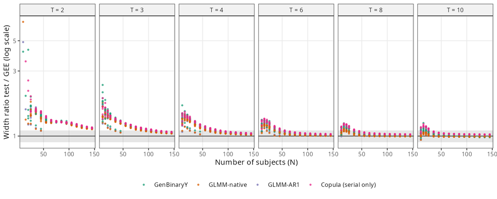

Rapporto di ampiezza fra l’intervallo del test e quello della GEE AR(1) con Fay e Graubard e t, sotto H1 (media geometrica per punto sui dataset in cui entrambi sono finiti; fascia 0,9-1,1).

Cosa guardare: il rapporto scende verso 1 al crescere di N e di T; resta sopra 1,1 solo con poche visite o pochi soggetti.

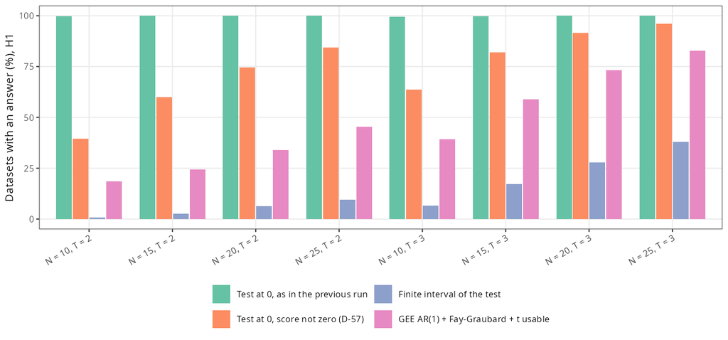

Situazioni piccole (2-3 visite, fino a 25 soggetti), sotto H1: quota di dataset con una risposta, media su meccanismi e scenari.

Cosa guardare: la distanza fra la prima barra (test come nel run precedente) e la seconda (test con le regole) sono i p-value fatti di errore di arrotondamento; la terza barra (intervallo finito) resta sotto quella della GEE in ogni disegno.

## Perche’ l’intervallo non e’ finito (H1)

`tables/V4_S7d2_explain_finite.csv`, percentuali sui dataset con disegno stimabile:

| ntime | Ng | datasets | finite | no_estimate | unbounded_with_noncomputable | unbounded_without | gee_ar1_fg_usable |
| --- | --- | --- | --- | --- | --- | --- | --- |
| 2 | 10 | 26340 | 0.8731 | 57.37 | 33.99 | 7.774 | 18.49 |
| 2 | 15-25 | 80900 | 6.165 | 47.84 | 23.71 | 22.29 | 34.59 |
| 2 | 35-65 | 102000 | 22.71 | 17.89 | 11.75 | 47.64 | 79.6 |
| 2 | 75-145 | 192000 | 72.02 | 1.357 | 1.781 | 24.84 | 98.56 |
| 3 | 10 | 26790 | 6.684 | 35.87 | 48.28 | 9.17 | 39.17 |
| 3 | 15-25 | 80980 | 27.61 | 19.41 | 43.83 | 9.15 | 71.61 |
| 3 | 35-65 | 102000 | 72.72 | 2.107 | 22.25 | 2.919 | 97.3 |
| 3 | 75-145 | 192000 | 97.28 | 0.02917 | 2.525 | 0.162 | 99.96 |
| 4 | 10 | 26880 | 15.65 | 21.89 | 58.9 | 3.567 | 57.33 |
| 4 | 15-25 | 81000 | 51.6 | 7.793 | 39.25 | 1.359 | 87.1 |
| 4 | 35-65 | 102000 | 90.91 | 0.3912 | 8.649 | 0.04902 | 99.44 |
| 4 | 75-145 | 192000 | 99.69 | 0 | 0.3125 | 0 | 100 |
| 6 | 10 | 26920 | 34.6 | 8.391 | 56.51 | 0.5014 | 80.67 |
| 6 | 15-25 | 81000 | 77.95 | 1.579 | 20.42 | 0.04568 | 96.63 |
| 6 | 35-65 | 102000 | 98.78 | 0.02647 | 1.194 | 0 | 99.93 |
| 6 | 75-145 | 192000 | 99.99 | 0 | 0.005208 | 0 | 100 |
| 8 | 10 | 23930 | 47.04 | 4.158 | 48.6 | 0.2089 | 89.55 |
| 8 | 15-25 | 72000 | 87.49 | 0.4542 | 12.05 | 0.01111 | 98.67 |
| 8 | 35-65 | 96000 | 99.81 | 0 | 0.1948 | 0 | 99.98 |
| 8 | 75-145 | 192000 | 100 | 0 | 0 | 0 | 100 |
| 10 | 10 | 23940 | 55.95 | 2.13 | 41.81 | 0.1169 | 93.89 |
| 10 | 15-25 | 72000 | 92.02 | 0.1361 | 7.839 | 0.001389 | 99.39 |
| 10 | 35-65 | 96000 | 99.95 | 0 | 0.05312 | 0 | 99.99 |
| 10 | 75-145 | 192000 | 100 | 0 | 0 | 0 | 100 |

## Ampiezza

`tables/V4_S7d2_width_groups.csv` (stessa base di PG7) e `tables/V4_S7d2_explain_width.csv` (dataset in cui sono finiti l’intervallo del test e quelli della GEE indipendente e AR(1); punti con almeno 20 dataset):

| group | points | ratio |
| --- | --- | --- |
| all | 2375 | 1.167 |
| N 10 | 155 | 1.642 |
| N 15-25 | 468 | 1.338 |
| N 35-65 | 600 | 1.146 |
| N 75-145 | 1152 | 1.064 |
| T = 10 | 384 | 1.025 |
| T = 2 | 401 | 1.533 |
| T = 3 | 402 | 1.216 |
| T = 4 | 402 | 1.151 |
| T = 6 | 402 | 1.086 |
| T = 8 | 384 | 1.046 |
| small designs | 215 | 1.946 |

| group | points | flip_over_ind | ind_over_ar1 | flip_over_ar1 |
| --- | --- | --- | --- | --- |
| all points | 2308 | 1.115 | 1.015 | 1.132 |
| T = 2 | 335 | 1.265 | 1.039 | 1.315 |
| T = 3 | 401 | 1.191 | 1.021 | 1.216 |
| T = 4 | 402 | 1.135 | 1.013 | 1.151 |
| T = 6 | 402 | 1.076 | 1.009 | 1.086 |
| T = 8 | 384 | 1.039 | 1.007 | 1.046 |
| T = 10 | 384 | 1.02 | 1.006 | 1.025 |
| N 10 | 131 | 1.148 | 1.113 | 1.278 |
| N 15-25 | 425 | 1.227 | 1.035 | 1.269 |
| N 35-65 | 600 | 1.139 | 1.006 | 1.146 |
| N 75-145 | 1152 | 1.061 | 1.003 | 1.064 |
| GLMM-AR1 | 488 | 1.107 | 1.008 | 1.116 |
| GLMM-native | 674 | 1.102 | 1.006 | 1.108 |
| GenBinaryY | 678 | 1.123 | 1.022 | 1.148 |
| Copula-AR1 | 468 | 1.13 | 1.027 | 1.162 |

## Il test a b0 = 0 con e senza le regole

`tables/V4_S7d2_flip_rules.csv`:

| label | version | set | points | mean_pu | mean_rate | n_hi | n_lo | points_lt20 |
| --- | --- | --- | --- | --- | --- | --- | --- | --- |
| H0 | as in S7d | all 2,376 points | 2376 | 99.98 | 5.276 | 0 | 4 | 0 |
| H0 | with D-57 rules | all 2,376 points | 2376 | 96.51 | 5.445 | 0 | 0 | 0 |
| H1 | as in S7d | all 2,376 points | 2376 | 99.98 | 20.92 | 1181 | 4 | 0 |
| H1 | with D-57 rules | all 2,376 points | 2376 | 96.85 | 21.09 | 1186 | 0 | 0 |
| H0 | as in S7d | copula (480 points) | 480 | 99.98 | 5.236 | 0 | 0 | 0 |
| H0 | with D-57 rules | copula (480 points) | 480 | 96.07 | 5.421 | 0 | 0 | 0 |
| H1 | as in S7d | copula (480 points) | 480 | 99.98 | 18.24 | 227 | 0 | 0 |
| H1 | with D-57 rules | copula (480 points) | 480 | 96.47 | 18.42 | 228 | 0 | 0 |
| H0 | as in S7d | small designs (T 2-3, N <= 25) | 216 | 99.88 | 3.888 | 0 | 4 | 0 |
| H0 | with D-57 rules | small designs (T 2-3, N <= 25) | 216 | 72.27 | 5.211 | 0 | 0 | 0 |
| H1 | as in S7d | small designs (T 2-3, N <= 25) | 216 | 99.89 | 4.254 | 0 | 4 | 0 |
| H1 | with D-57 rules | small designs (T 2-3, N <= 25) | 216 | 74.01 | 5.543 | 0 | 0 | 0 |
| H0 | as in S7d | study mechanisms (1,896 points) | 1896 | 99.98 | 5.286 | 0 | 4 | 0 |
| H0 | with D-57 rules | study mechanisms (1,896 points) | 1896 | 96.62 | 5.451 | 0 | 0 | 0 |
| H1 | as in S7d | study mechanisms (1,896 points) | 1896 | 99.98 | 21.6 | 954 | 4 | 0 |
| H1 | with D-57 rules | study mechanisms (1,896 points) | 1896 | 96.95 | 21.76 | 958 | 0 | 0 |

Situazioni piccole, senza effetto, test con le regole, per N e T (`tables/V4_S7d2_flip_rules_dp.csv`):

| N | ntime | pu_as_S7d | pu_rules | rate_rules |
| --- | --- | --- | --- | --- |
| 10 | 2 | 99.92 | 38.01 | 5.872 |
| 15 | 2 | 99.98 | 58.15 | 5.109 |
| 20 | 2 | 99.98 | 72.8 | 4.904 |
| 25 | 2 | 99.98 | 83.08 | 5.296 |
| 10 | 3 | 99.41 | 60.8 | 5.023 |
| 15 | 3 | 99.83 | 79.65 | 4.802 |
| 20 | 3 | 99.97 | 90.23 | 5.184 |
| 25 | 3 | 100 | 95.43 | 5.502 |

# Cosa e’ girato

- Commit: pre-registrazione `3235dbe`; codice, controlli e aggregazione prima del run `b431042`; correzione di un conteggio in D-57 `68309d6`.
- Script: `R/s7d2/s7d2_ci.R` (intervallo), `s7d2_common.R`, `s7d2_run.R`, `s7d2_thermal_guard.sh`, `s7d2_md5.sh`, `s7d2_gate_check.R`, `s7d2_timing.R`, `s7d2_agg.R`; diagnosi prima del run `s7d2_islands.R`, `s7d2_diag17.R`, `s7d2_coefgap.R`, `s7d2_ugap.R`, `s7d2_fuzzy.R`, `s7d2_onecase.R`; dopo il run `s7d2_explain.R`, `s7d2_flip_rules.R`, `s7d2_width_groups.R`, `s7d2_zerowidth.R`, `s7d2_figs.R`.
- Run: 47.520 chunk, 4.752.000 dataset, 7,98 ore, 22-26 processi, 0 falliti (`reports/morris/S7d2_logs/run.txt`, `results_v4/S7d2/run_progress.log`).
- md5 di `results_full/`: 28.800 file, prima = dopo = lista di S7b (`reports/morris/S7d2_logs/md5_before.txt`, `md5_after.txt`).

# Appendice

## Cancelli calcolati nel run (`tables/V4_S7d2_gates.csv`)

| gate | check | value | target | pass |
| --- | --- | --- | --- | --- |
| GG1 | chunk files | 47520 | 47520 | TRUE |
| GG1 | replicates | 4752000 | 4752000 | TRUE |
| GG1 | unique replicate keys | 4752000 | 4752000 | TRUE |
| GG1 | md5 before = after | 1 | 1 | TRUE |
| GG1 | md5 before = S7b list | 1 | 1 | TRUE |
| GG2 | n_obs and sum_y equal to S7d/S7e | 0 | 0 | TRUE |
| GG2 | p0 s7d_flip() = saved p_flip | 0 | 0 | TRUE |
| GG2 | p0 new function = saved p_flip | 0 | 0 | TRUE |
| GG2 | CI errors | 0 | 0 | TRUE |
| GG4 | intervals checked | 4502000 | NA | TRUE |
| GG4 | lo <= est <= hi violated | 0 | 0 | TRUE |
| GG4 | p < 0.05 at a reported end | 0 | 0 | TRUE |
| GG4 | not rejected 1e-4 beyond a finite end | 78 | 0 | FALSE |
| GG4 | of which p not computable 1e-4 beyond | 78 | NA | NA |
| GG4 | reported: finite intervals of width 0 | 51 | NA | NA |

Intervalli di GG4 con un punto non calcolabile subito oltre l’estremo (`tables/V4_S7d2_GG4_detail.csv`):

| why_beyond | p_rej_below_005 | end_accepted | N |
| --- | --- | --- | --- |
| reduced fit failed | TRUE | TRUE | 51 |
| reduced fit diverged | TRUE | TRUE | 27 |

## Motivi di dati mancanti (`tables/V4_S7d2_reasons.csv`)

| what | reason | N |
| --- | --- | --- |
| no interval | \|estimate\| >= 10 | 246500 |
| no interval | full fit diverged | 705 |
| no interval | full fit failed | 59 |
| test at truth not usable | score numerically zero | 155200 |
| test at truth not usable | information singular | 779 |
| test at truth not usable | reduced fit diverged | 613 |
| test at truth not usable | reduced fit failed | 84 |
| test at truth not usable | zero score variance | 11 |
| interval not finite | both unbounded | 287100 |
| interval not finite | upper unbounded | 267900 |
| interval not finite | lower unbounded | 213000 |

## Medie per meccanismo, braccio e T (`tables/V4_S7d2_by_T.csv`)

| mech | label | ntime | points | cov_t | cov_i | pfin | wid_med | gm_ratio | cov_g | pu_g | n_lo_t | n_hi_t | pu_flip_s7d | pu_flip_guard | rate_flip_guard |
| --- | --- | --- | --- | --- | --- | --- | --- | --- | --- | --- | --- | --- | --- | --- | --- |
| copula | manual | 2 | 80 | 94.48 | 96.76 | 41.27 | 4.464 | 1.571 | 97.39 | 74.73 | 0 | 0 | 99.98 | 88.43 | 5.523 |
| copula | manual | 3 | 80 | 94.68 | 95.3 | 68.66 | 2.34 | 1.259 | 94.89 | 87.58 | 0 | 0 | 99.93 | 94.05 | 5.316 |
| copula | manual | 4 | 80 | 94.58 | 94.9 | 79.65 | 1.51 | 1.195 | 94.61 | 92.59 | 0 | 0 | 99.96 | 96.4 | 5.421 |
| copula | manual | 6 | 80 | 94.6 | 94.7 | 89.24 | 0.8189 | 1.135 | 95 | 97.02 | 0 | 0 | 99.98 | 98.55 | 5.401 |
| copula | manual | 8 | 80 | 94.65 | 94.67 | 93.02 | 0.5329 | 1.098 | 95.41 | 98.59 | 0 | 0 | 100 | 99.34 | 5.353 |
| copula | manual | 10 | 80 | 94.49 | 94.5 | 94.91 | 0.386 | 1.072 | 95.38 | 99.32 | 0 | 0 | 100 | 99.69 | 5.514 |
| copula | mmlb | 2 | 80 | 94.52 | 96.71 | 43.1 | 4.395 | 1.551 | 96.85 | 75.41 | 0 | 0 | 99.99 | 89 | 5.95 |
| copula | mmlb | 3 | 80 | 94.62 | 95.22 | 70.21 | 2.291 | 1.237 | 95.04 | 88.26 | 0 | 0 | 99.93 | 94.62 | 7.057 |
| copula | mmlb | 4 | 80 | 94.53 | 94.8 | 81.07 | 1.464 | 1.172 | 94.97 | 93.33 | 0 | 0 | 99.95 | 96.97 | 9.05 |
| copula | mmlb | 6 | 80 | 94.45 | 94.52 | 89.88 | 0.792 | 1.114 | 95.35 | 97.53 | 0 | 0 | 99.99 | 98.92 | 16.65 |
| copula | mmlb | 8 | 80 | 94.55 | 94.59 | 93.13 | 0.522 | 1.08 | 95.69 | 98.88 | 0 | 0 | 100 | 99.53 | 28.79 |
| copula | mmlb | 10 | 80 | 94.34 | 94.34 | 94.65 | 0.3827 | 1.064 | 95.36 | 99.47 | 0 | 0 | 100 | 99.79 | 43.01 |
| study mechanisms | manual | 2 | 322 | 94.35 | 96.81 | 39.53 | 4.985 | 1.556 | 97.65 | 74.86 | 0 | 0 | 99.99 | 89.59 | 5.631 |
| study mechanisms | manual | 3 | 322 | 94.61 | 95.3 | 69.79 | 2.412 | 1.227 | 95.5 | 89.25 | 0 | 0 | 99.95 | 95.17 | 5.386 |
| study mechanisms | manual | 4 | 322 | 94.66 | 94.92 | 81.28 | 1.457 | 1.164 | 95.18 | 94.12 | 0 | 0 | 99.96 | 97.25 | 5.344 |
| study mechanisms | manual | 6 | 322 | 94.57 | 94.65 | 90.66 | 0.7314 | 1.096 | 95.2 | 97.74 | 0 | 0 | 99.99 | 98.89 | 5.437 |
| study mechanisms | manual | 8 | 304 | 94.54 | 94.58 | 94.34 | 0.4506 | 1.056 | 95.28 | 98.9 | 0 | 0 | 99.99 | 99.44 | 5.468 |
| study mechanisms | manual | 10 | 304 | 94.58 | 94.59 | 95.96 | 0.31 | 1.027 | 95.42 | 99.36 | 0 | 0 | 100 | 99.7 | 5.438 |
| study mechanisms | mmlb | 2 | 322 | 94.32 | 96.76 | 41.05 | 4.919 | 1.529 | 97.36 | 75.5 | 0 | 0 | 99.99 | 90.12 | 6.035 |
| study mechanisms | mmlb | 3 | 322 | 94.56 | 95.22 | 71.11 | 2.346 | 1.21 | 95.56 | 89.79 | 0 | 0 | 99.95 | 95.67 | 6.987 |
| study mechanisms | mmlb | 4 | 322 | 94.59 | 94.84 | 82.39 | 1.405 | 1.145 | 95.41 | 94.65 | 0 | 0 | 99.97 | 97.66 | 9.374 |
| study mechanisms | mmlb | 6 | 322 | 94.5 | 94.57 | 91.09 | 0.698 | 1.079 | 95.54 | 98.12 | 0 | 0 | 99.99 | 99.15 | 19.87 |
| study mechanisms | mmlb | 8 | 304 | 94.57 | 94.6 | 94.6 | 0.4307 | 1.037 | 95.69 | 99.15 | 0 | 0 | 100 | 99.61 | 37.26 |
| study mechanisms | mmlb | 10 | 304 | 94.47 | 94.48 | 96.02 | 0.3046 | 1.015 | 95.6 | 99.51 | 0 | 0 | 100 | 99.79 | 53.7 |

## Da dove vengono i numeri del riassunto

| frase del riassunto | tabella o file, riga | valore letto |
| --- | --- | --- |
| contiene il valore vero in 94,5 simulazioni su 100 | `V4_S7d2_predictions.csv`, PG1 | 94,50 |
| la GEE raccomandata in 95,8 | `V4_S7d2_predictions.csv`, PG8 | 95,80 |
| in nessuna situazione fuori taratura | `V4_S7d2_predictions.csv`, PG2 e PG3 | 0 e 0 |
| finiti in 14 su 100 con 2-3 visite e fino a 25 soggetti | `V4_S7d2_predictions.csv`, PG6 | 13,61 |
| la GEE dà un intervallo in 47 | `V4_S7d2_small.csv`, mmlb, small, pu_g | 47,03 |
| finito in 79 su 100 sull’intera griglia | `V4_S7d2_predictions.csv`, PG5 | 78,99 |
| più largo in media del 17% | `V4_S7d2_predictions.csv`, PG7 | 1,167 |
| 6% con almeno 75 soggetti, 3% con 10 visite | `V4_S7d2_width_groups.csv`, N 75-145 e T = 10 | 1,06 e 1,03 |
| quasi il doppio con 2-3 visite e fino a 25 soggetti | `V4_S7d2_width_groups.csv`, small designs | 1,95 |
| GEE indipendente 2% più larga della AR(1) | `V4_S7d2_explain_width.csv`, all points, ind_over_ar1 | 1,02 |
| 28 su 100 con 2-3 visite e fino a 25 soggetti | `V4_S7d2_flip_rules.csv`, H0, small: 99,88 - 72,27 | 27,6 |
| circa 6 su 10 con 10 soggetti e 2 visite | `V4_S7d2_flip_rules_dp.csv`, H0, N 10, T 2: 99,92 - 38,01 | 61,9 |
| 3,5 su 100 sull’intera griglia | `V4_S7d2_flip_rules.csv`, H0, all: 99,98 - 96,51 | 3,47 |
| il test risponde in 72 su 100 | `V4_S7d2_flip_rules.csv`, H0, small, with rules | 72,27 |
| la GEE raccomandata in 46 | `V4_S7d2_small.csv`, manual, small, pu_g | 45,94 |
| 5,2 falsi positivi su 100 in quelle situazioni | `V4_S7d2_flip_rules.csv`, H0, small, with rules | 5,211 |
| 5,4 sull’intera griglia | `V4_S7d2_flip_rules.csv`, H0, all, with rules | 5,445 |
| mai fuori taratura | `V4_S7d2_flip_rules.csv`, H0, with rules, n_hi e n_lo | 0 e 0 |
| il run è durato 8,0 ore | `results_v4/S7d2/run_progress.log`, riga DONE | 7,98 h |
| 0,14 secondi per dataset | `results_v4/S7d2/timing_pilot.csv`, media di wall_per_rep | 0,139 |